# Timing matters: Viticultural land use determines responses in structure and function of fungal stream communities across one growing season

### 2.2.1 model building

linear mixed model with the stream and stream + treatment (to consider the technical replicates) as random factor, check if both explanatory variables (namely time.point and treatment) interact

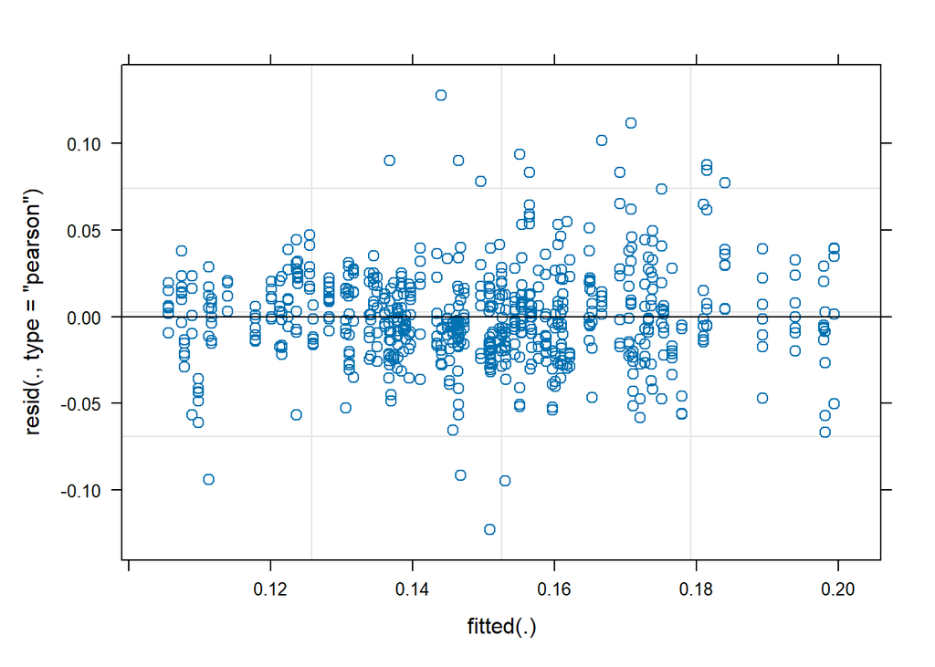

```r
# create the second random factor stream + treatment
leaf_weight$fac_repli <- paste(leaf_weight$stream, leaf_weight$treatment)

DLM_lmer <- lmer(DLM ~ time.point + treatment + time.point:treatment + (1|stream) + (1|fac_repli), data = leaf_weight)

plot(DLM_lmer) # point cloud looDLMs evenly distributed --> normal distribution
```

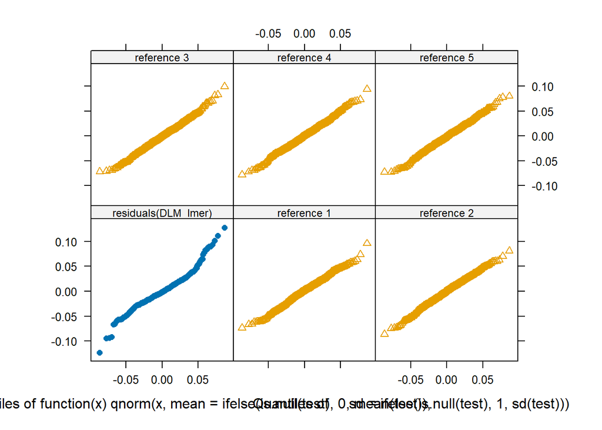

```r
qreference(residuals(DLM_lmer)) # normality not perfect, but oDLM
```

```r
drop1(DLM_lmer, test = 'Chisq')
```

```
## Single term deletions
##
## Model:
## DLM ~ time.point + treatment + time.point:treatment + (1 | stream) +
##     (1 | fac_repli)
##                      npar     AIC    LRT  Pr(Chi)
## <none>                    -2822.7
## time.point:treatment    6 -2814.2 20.468 0.002285 **
## ---
## Signif. codes:  0 '***' 0.001 '**' 0.01 '*' 0.05 '.' 0.1 ' ' 1
```

```r
# interaction is highly significant (p = 0.002285)
# checDLM next at which time points is there a difference between treatments and where not
anova(DLM_lmer)
```

```
## Analysis of Variance Table
##                      npar   Sum Sq   Mean Sq F value
## time.point              3 0.078875 0.0262917 33.6707
## treatment               2 0.040313 0.0201567 25.8138
## time.point:treatment    6 0.016076 0.0026793  3.4312
```

### 2.2.2 check differences between the treatments at each timepoint

conduct pairwise comparison

```r
DLM_inter <- lsmeans(DLM_lmer, ~ treatment | time.point )

DLM_inter_dunn1 <- contrast(DLM_inter, 'pairwise')
(DLM_inter_dunn_sum1 <- summary(DLM_inter_dunn1, infer = TRUE, adjust = 'mvt'))
```

```
## time.point = April:
##  contrast            estimate      SE    df  lower.CL upper.CL t.ratio p.value
##  forest - transplant  0.00485 0.00616  70.4 -9.90e-03  0.01961   0.788  0.7113
##  forest - viti        0.02620 0.00613  69.5  1.15e-02  0.04088   4.273  0.0002
##  transplant - viti    0.02134 0.00625  73.5  6.40e-03  0.03628   3.417  0.0029
##
## time.point = August:
##  contrast            estimate      SE    df  lower.CL upper.CL t.ratio p.value
##  forest - transplant  0.01341 0.00604  65.7 -1.08e-03  0.02790   2.220  0.0752
##  forest - viti        0.04265 0.00600  64.3  2.83e-02  0.05705   7.105  <.0001
##  transplant - viti    0.02924 0.00601  64.3  1.48e-02  0.04365   4.869  <.0001
##
## time.point = June:
##  contrast            estimate      SE    df  lower.CL upper.CL t.ratio p.value
##  forest - transplant -0.00675 0.00625  74.3 -2.17e-02  0.00819  -1.080  0.5292
##  forest - viti        0.01447 0.00618  71.7 -3.34e-04  0.02927   2.340  0.0567
##  transplant - viti    0.02121 0.00604  65.8  6.74e-03  0.03568   3.515  0.0022
##
## time.point = September:
##  contrast            estimate      SE    df  lower.CL upper.CL t.ratio p.value
##  forest - transplant  0.01813 0.00738 109.4  5.88e-04  0.03567   2.456  0.0411
##  forest - viti        0.03567 0.00734 108.0  1.82e-02  0.05312   4.858  <.0001
##  transplant - viti    0.01755 0.00741 111.3 -6.25e-05  0.03516   2.367  0.0510
##
## Degrees-of-freedom method: kenward-roger
## Confidence level used: 0.95
## Conf-level adjustment: mvt method for 3 estimates
## P value adjustment: mvt method for 3 tests
```

## 2.3 decompostion rate k

```r
leaf_weight_k$k <- (-log((leaf_weight_k$afdm_end / leaf_weight_k$afdm_start)) )/
                   (leaf_weight_k$mean_temp * leaf_weight_k$number.days)
```

### 2.3.1 Statistical analysis k

investigate data

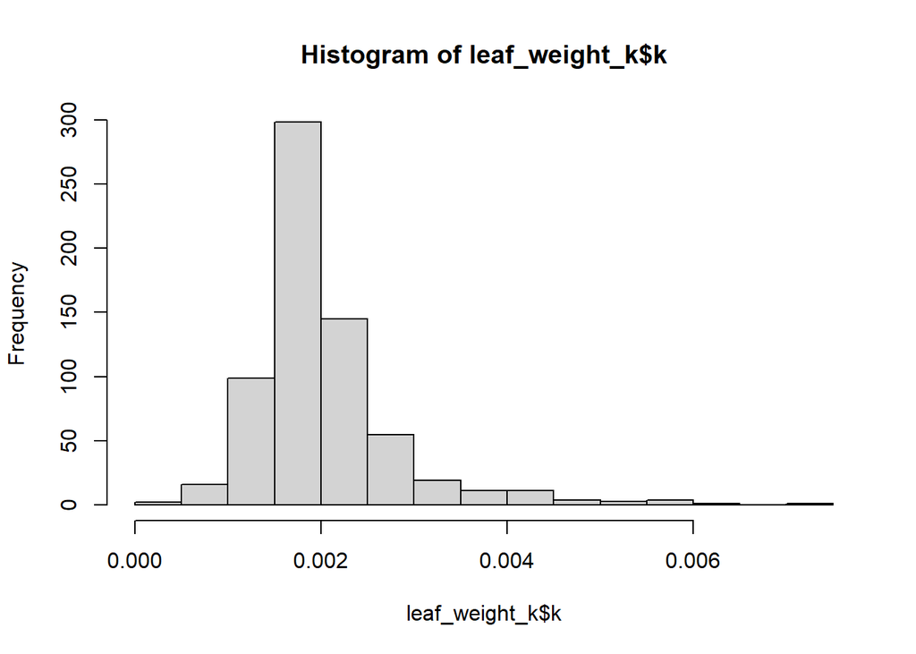

```r
hist(leaf_weight_k$k)
```

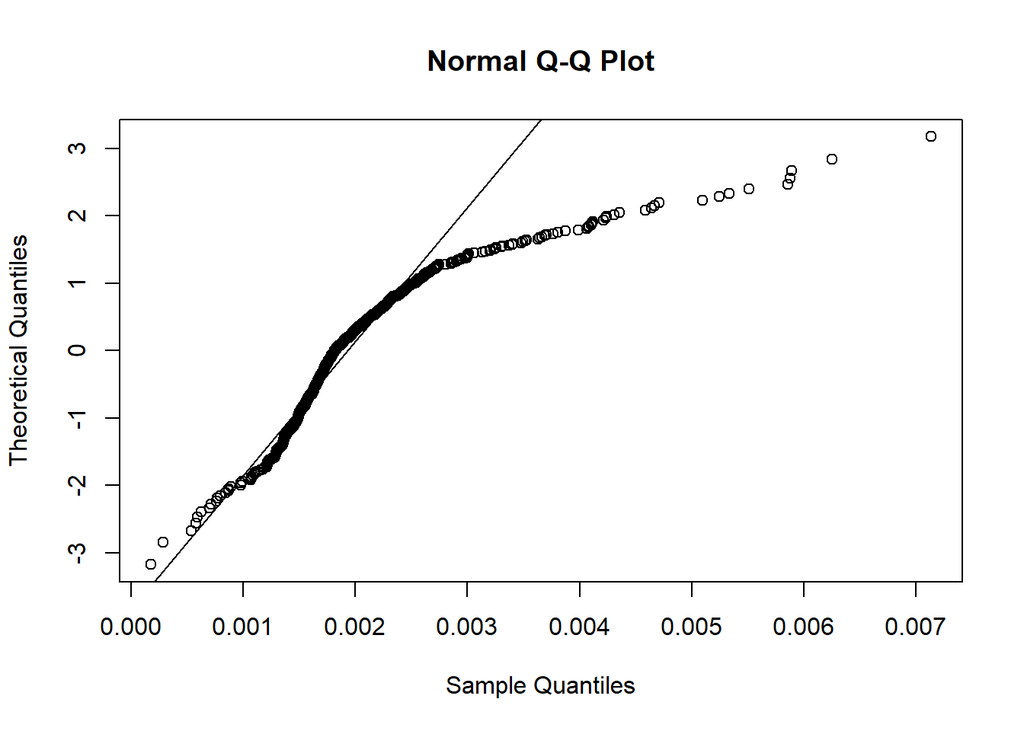

```r
qqnorm(leaf_weight_k$k, datax=TRUE)
qqline(leaf_weight_k$k, datax=TRUE)
```

```r
library(parameters)
skewness(leaf_weight_k$k) # 2.268
```

```
## Skewness |    SE
## ----------------
##    2.268 | 0.094
```

data not normally distributed. But due to the logarithmic character of the variable a transformation is not possible and the non-normality is not driven by single outliers, but by a right tail. This tail suggests that a linear model is still best way to go and other distributions are not better suited.

##### 2.3.1.0.1 model with decomposition rate k

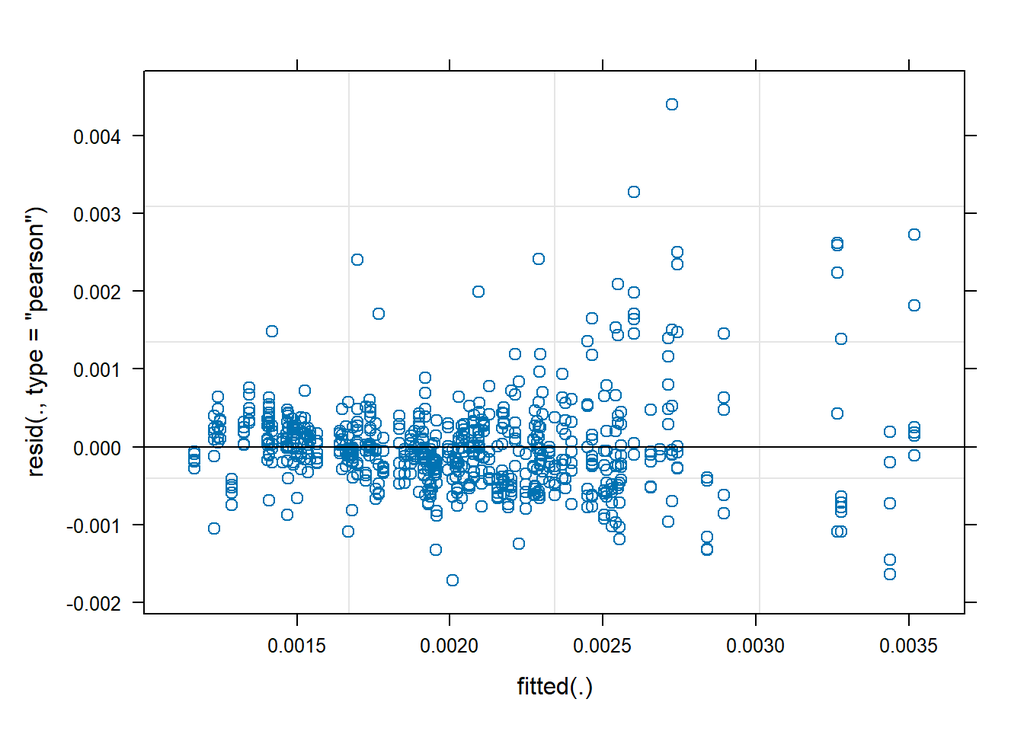

```r
# create the second random factor stream + treatment
leaf_weight_k$fac_repli <- paste(leaf_weight_k$stream, leaf_weight_k$treatment)

k_lmer <- lmer(k ~ time.point + treatment + time.point:treatment + (1|stream) + (1|fac_repli), data = leaf_weight_k)

plot(k_lmer) # point cloud looks evenly distributed --> normal distribution
```

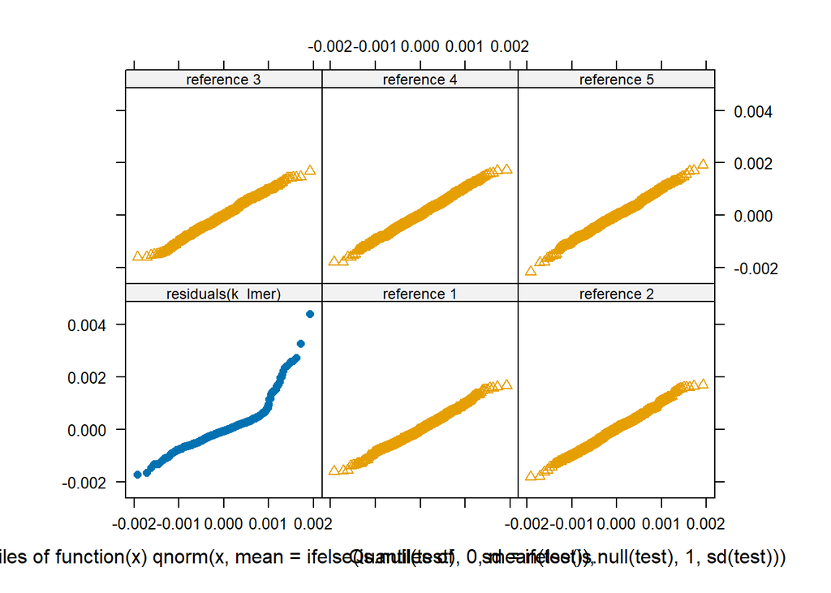

```r
qreference(residuals(k_lmer)) # normality not perfect, but ok
```

```r
drop1(k_lmer, test = 'Chisq')
```

```
## Single term deletions
##
## Model:
## k ~ time.point + treatment + time.point:treatment + (1 | stream) +
##     (1 | fac_repli)
##                      npar     AIC    LRT  Pr(Chi)
## <none>                    -7922.8
## time.point:treatment    6 -7913.1 21.733 0.001353 **
## ---
## Signif. codes:  0 '***' 0.001 '**' 0.01 '*' 0.05 '.' 0.1 ' ' 1
```

```r
# interaction is highly significant (p = 0.001353 **)
# check next at which time points is there a difference between treatments and where not
anova(k_lmer)
```

```
## Analysis of Variance Table
##                      npar     Sum Sq    Mean Sq F value
## time.point              3 4.8568e-05 1.6189e-05 42.3102
## treatment               2 1.4484e-05 7.2419e-06 18.9265
## time.point:treatment    6 8.3070e-06 1.3844e-06  3.6182
```

#### 2.3.1.1 check differences between the treatments at each timepoint

conduct pairwise comparison

```r
k_inter <- lsmeans(k_lmer, ~ treatment | time.point )
k_inter_dunn1 <- contrast(k_inter, 'pairwise')
(k_inter_dunn_sum1 <- summary(k_inter_dunn1, infer = TRUE, adjust = 'mvt'))
```

```
## time.point = April:
##  contrast             estimate       SE    df  lower.CL upper.CL t.ratio
##  forest - transplant -1.27e-05 0.000129  90.6 -3.19e-04 2.94e-04  -0.099
##  forest - viti        2.76e-04 0.000128  89.4 -2.91e-05 5.81e-04   2.156
##  transplant - viti    2.89e-04 0.000131  94.4 -2.23e-05 5.99e-04   2.210
##  p.value
##   0.9946
##   0.0845
##   0.0746
##
## time.point = August:
##  contrast             estimate       SE    df  lower.CL upper.CL t.ratio
##  forest - transplant  1.78e-04 0.000126  84.2 -1.22e-04 4.78e-04   1.413
##  forest - viti        8.19e-04 0.000125  82.1  5.21e-04 1.12e-03   6.558
##  transplant - viti    6.41e-04 0.000125  82.2  3.43e-04 9.40e-04   5.132
##  p.value
##   0.3388
##   <.0001
##   <.0001
##
## time.point = June:
##  contrast             estimate       SE    df  lower.CL upper.CL t.ratio
##  forest - transplant -2.33e-04 0.000131  96.0 -5.44e-04 7.77e-05  -1.785
##  forest - viti        2.17e-04 0.000129  92.4 -9.03e-05 5.25e-04   1.683
##  transplant - viti    4.50e-04 0.000126  84.3  1.51e-04 7.50e-04   3.584
##  p.value
##   0.1799
##   0.2172
##   0.0017
##
## time.point = September:
##  contrast             estimate       SE    df  lower.CL upper.CL t.ratio
##  forest - transplant  2.04e-04 0.000156 130.0 -1.66e-04 5.74e-04   1.305
##  forest - viti        4.94e-04 0.000155 128.4  1.26e-04 8.62e-04   3.182
##  transplant - viti    2.90e-04 0.000157 132.6 -8.14e-05 6.62e-04   1.852
##  p.value
##   0.3950
##   0.0052
##   0.1570
##
## Degrees-of-freedom method: kenward-roger
## Confidence level used: 0.95
## Conf-level adjustment: mvt method for 3 estimates
## P value adjustment: mvt method for 3 tests
```

##### 2.3.1.1.1 create Figure S4

create plot decomposition rates k

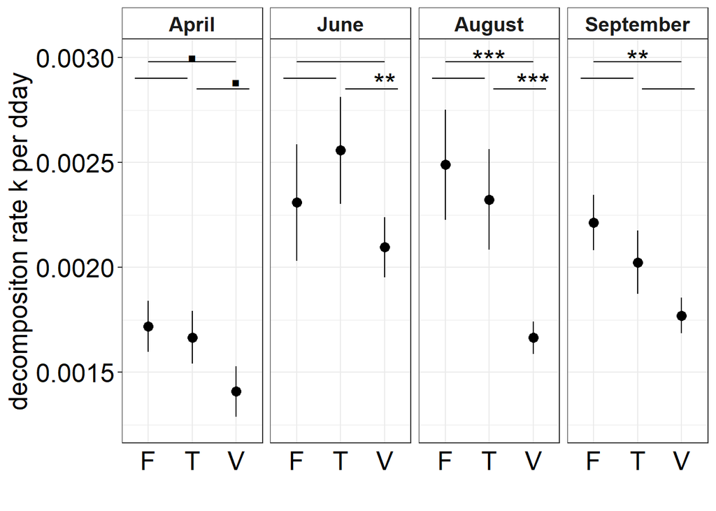

```r
k_CI <- group.CI(k ~ time.point + treatment,
                   data = leaf_weight_k,
                   ci = 0.95)

# change order of the factor time point
k_CI$time.point <- factor(k_CI$time.point,
                             levels = c("April", "June", "August", "September"))

# rename transplant treatments in order to enable fit to the plot
k_CI$treatment <- gsub("transplant", "T", k_CI$treatment)
k_CI$treatment <- gsub("forest", "F", k_CI$treatment)
k_CI$treatment <- gsub("viti", "V", k_CI$treatment)

# for indication of significance
ann_text_1 <- data.frame(treatment = "T", k.mean = 0.003, lab = "\U25AA",
                       time.point = factor("April",levels = c("April", "June", "August", "September")))
# Difference forest - viti April
ann_text_2 <- data.frame(treatment = "V", k.mean = 0.002885, lab = "\U25AA",
                       time.point = factor("April",levels = c("April", "June", "August", "September")))
# Difference transplant - viti April
# ann_text_3 <- data.frame(treatment = "T", k.mean = 0.20, lab = "\U25AA",  # unicode hex for square
#                        time.point = factor("June",levels = c("April", "June", "August", "September")))
# # Difference forest - viti June
ann_text_4 <- data.frame(treatment = "V", k.mean = 0.00288, lab = "**",
                       time.point = factor("June",levels = c("April", "June", "August", "September")))
# Difference transplant - viti June
# ann_text_5 <- data.frame(treatment = "F", k.mean = 0.195, lab = "\U25AA",
#                        time.point = factor("August",levels = c("April", "June", "August", "September")))
# # Difference forest - transplant August
ann_text_6 <- data.frame(treatment = "T", k.mean = 0.00299, lab = "***",
                       time.point = factor("August",levels = c("April", "June", "August", "September")))
# Difference forest - viti August
ann_text_7 <- data.frame(treatment = "V", k.mean = 0.00288, lab = "***",
                       time.point = factor("August",levels = c("April", "June", "August", "September")))
# Difference transplant - viti August
# ann_text_8 <- data.frame(treatment = "F", k.mean = 0.1945, lab = "*",
#                        time.point = factor("September",levels = c("April", "June", "August", "September")))
# # Difference forest - transplant September
ann_text_9 <- data.frame(treatment = "T", k.mean = 0.00299, lab = "**",
                       time.point = factor("September",levels = c("April", "June", "August", "September")))
# Difference forest - viti September
# ann_text_10 <- data.frame(treatment = "V", k.mean = 0.195, lab = "\U25AA",
#                        time.point = factor("September",levels = c("April", "June", "August", "September")))
# # Difference transplant - viti September
ann_text <- rbind(ann_text_1, ann_text_2, ann_text_4,  ann_text_6, ann_text_7,  ann_text_9)


# for lines below significance indications
fv <- data.frame(a = c(1.0, 2, 2, 3), b = rep(c(0.00298), 4))
mv <- data.frame(a = c(2.1, 2.5, 3, 3.3), b = rep(c(0.00285), 4))
nv <- data.frame(a = c(0.7, 1, 1, 1.9), b = rep(c(0.0029), 4))

p1_k <-  ggplot(k_CI, aes(x = treatment, y = k.mean)) +
  geom_pointrange(aes(y = k.mean, ymin = k.lower, ymax = k.upper))+
  geom_point(mapping = aes(y = k.mean), size = 3) +
  facet_wrap(~time.point, nrow = 1) +
  ylab('decompositon rate k per dday')+
  xlab("")+
  ylim(0.00125, 0.003)+
  geom_text(data = ann_text, label = ann_text$lab, cex = 7)+
  geom_line(data = fv, aes(x = a, y = b)) +
  geom_line(data = mv, aes(x = a, y = b)) +
  geom_line(data = nv, aes(x = a, y = b)) +
  theme_bw()+
  theme(axis.text.x = element_text(size = 18, color="black"), axis.ticks.x = element_blank(),
         axis.text.y = element_text(colour="black", size = 18),
         legend.position="none", strip.text.x = element_text(face = "bold"),
         text = element_text(size=18), plot.title = element_blank(),strip.background = element_rect(fill="white"))

p1_k
```

```r
svg(filename="Figure_S4_decomposition_rate.svg", width=10, height=7.5, pointsize=12)
p1_k
dev.off()
```

```r
# unnecessary lines for significance will be removed manually in the vector graphic
```

##### 2.3.1.1.2 create Figure 1

create plot DLM

[figure not shown]

```r
DLM_CI <- group.CI(DLM ~ time.point + treatment,
                   data = leaf_weight,
                   ci = 0.95)

# change order of the factor time point
DLM_CI$time.point <- factor(DLM_CI$time.point,
                             levels = c("April", "June", "August", "September"))

# rename transplant treatments in order to enable fit to the plot
DLM_CI$treatment <- gsub("transplant", "T", DLM_CI$treatment)
DLM_CI$treatment <- gsub("forest", "F", DLM_CI$treatment)
DLM_CI$treatment <- gsub("viti", "V", DLM_CI$treatment)

# for indication of significance
ann_text_1 <- data.frame(treatment = "T", DLM.mean = 0.199, lab = "**",
                       time.point = factor("April",levels = c("April", "June", "August", "September")))
# Difference forest - viti April
ann_text_2 <- data.frame(treatment = "V", DLM.mean = 0.193, lab = "**",
                       time.point = factor("April",levels = c("April", "June", "August", "September")))
# Difference transplant - viti April
ann_text_3 <- data.frame(treatment = "T", DLM.mean = 0.20, lab = "\U25AA",  # unicode hex for square
                       time.point = factor("June",levels = c("April", "June", "August", "September")))
# Difference forest - viti June
ann_text_4 <- data.frame(treatment = "V", DLM.mean = 0.193, lab = "**",
                       time.point = factor("June",levels = c("April", "June", "August", "September")))
# Difference transplant - viti June
ann_text_5 <- data.frame(treatment = "F", DLM.mean = 0.195, lab = "\U25AA",
                       time.point = factor("August",levels = c("April", "June", "August", "September")))
# Difference forest - transplant August
ann_text_6 <- data.frame(treatment = "T", DLM.mean = 0.199, lab = "***",
                       time.point = factor("August",levels = c("April", "June", "August", "September")))
# Difference forest - viti August
ann_text_7 <- data.frame(treatment = "V", DLM.mean = 0.193, lab = "***",
                       time.point = factor("August",levels = c("April", "June", "August", "September")))
# Difference transplant - viti August
ann_text_8 <- data.frame(treatment = "F", DLM.mean = 0.1945, lab = "*",
                       time.point = factor("September",levels = c("April", "June", "August", "September")))
# Difference forest - transplant September
ann_text_9 <- data.frame(treatment = "T", DLM.mean = 0.199, lab = "***",
                       time.point = factor("September",levels = c("April", "June", "August", "September")))
# Difference forest - viti September
ann_text_10 <- data.frame(treatment = "V", DLM.mean = 0.195, lab = "\U25AA",
                       time.point = factor("September",levels = c("April", "June", "August", "September")))
# Difference transplant - viti September
ann_text <- rbind(ann_text_1, ann_text_2, ann_text_3, ann_text_4, ann_text_5, ann_text_6, ann_text_7, ann_text_8, ann_text_9, ann_text_10)

# for lines below significance indications
fv <- data.frame(a = c(1.0, 2, 2, 3), b = rep(c(0.198), 4))
mv <- data.frame(a = c(2.1, 2.5, 3, 3.3), b = rep(c(0.192), 4))
nv <- data.frame(a = c(0.7, 1, 1, 1.9), b = rep(c(0.1935), 4))

p1_DLM <-  ggplot(DLM_CI, aes(x = treatment, y = DLM.mean)) +
  geom_pointrange(aes(y = DLM.mean, ymin = DLM.lower, ymax = DLM.upper))+
  geom_point(mapping = aes(y = DLM.mean), size = 3) +
  facet_wrap(~time.point, nrow = 1) +
  ylab('Decomposed leaf mass [%] per dday')+
  xlab("")+
  ylim(0.11, 0.20)+
  geom_text(data = ann_text, label = ann_text$lab, cex = 7)+
  geom_line(data = fv, aes(x = a, y = b)) +
  geom_line(data = mv, aes(x = a, y = b)) +
  geom_line(data = nv, aes(x = a, y = b)) +
  theme_bw()+
  theme(axis.text.x = element_text(size = 18, color="black"), axis.ticks.x = element_blank(),
         axis.text.y = element_text(colour="black", size = 18),
         legend.position="none", strip.text.x = element_text(face = "bold"),
         text = element_text(size=18), plot.title = element_blank(),strip.background = element_rect(fill="white"))

p1_DLM
```

```r
svg(filename="Figure_1_DLM.svg", width=10, height=7.5, pointsize=12)
p1_DLM
dev.off()
```

```r
# unnecessary lines for significance will be removed manually in the vector graphic
```

# 3 Fungal communities

with the information of the fungal communities (via morphological identification and metabarcoding), we will look at following endpoints:  
* taxa richness  
* community structure/community composition  
* identification of indicator taxa

## 3.1 Conidia

information retrieved from morphological identification

### 3.1.1 Prepare data

read dataframe

```r
conidia <- read.table(file.path(prj, "4_conidia_data.csv"),
                      header = TRUE,
                      sep = ";",
                      na.strings = c("NR", "NA"))

# rename treatment
conidia$treatment <- gsub("move", "transplant", conidia$treatment)
conidia$treatment <-gsub("vine", "viti", conidia$treatment)
```

calculate the number of spores related to AFDM of used leaves

```r
# April Russbach transplant 3: take only half the leaf disk mass since
# twice the amount of stream water was in vial but still 2 ml were taken for Mixed-sample
leaf_weight_all_info[leaf_weight_all_info$time.point=="April" & leaf_weight_all_info$stream=="Russbach" & leaf_weight_all_info$treatment=="transplant" & leaf_weight_all_info$replicate==3, "conidia_AFDM"] <- 0.5 * leaf_weight_all_info[leaf_weight_all_info$time.point=="April" & leaf_weight_all_info$stream=="Russbach" & leaf_weight_all_info$treatment=="transplant" & leaf_weight_all_info$replicate==3, "conidia_AFDM"]

# volume sample and used AFDM has to be calculated
conid_sum <- leaf_weight_all_info %>%
  filter(!is.na(conidia_AFDM)) %>%
  group_by(time.point, stream, treatment) %>%
  summarise(nr_reps = n(), vol_ml = nr_reps*(10 + 0.855 + 0.019), sum_conidia_AFDM = sum(conidia_AFDM, na.rm = TRUE))
# vol_ml: The calculated volume refers to the sum of all replicates. For one replicate, we used 10 mL of stream water and added 0.855 mL of formadehyde to preserve and 0.019 mL of tween to prevent clogging of the conidia
# sum_conidia_AFDM: summarize all AFDM of conidia disks per stream - treatment - timepoint combination since the replicates were pooled to reduce number of analysed samples
# nr_reps refers to the number of replicates which were pooled to create one sample

# merge with conidia table
conidia <- merge(conidia, conid_sum, by = c("time.point", "stream", "treatment"))

# change order of columns
conidia <- conidia[ ,c(1:6, 64:66, 7:63)]

# Kropsbach viti August -> take half the filtered volume since 4 mL were taken per replicate for mixed-sample instead of 2 ml.
conidia[conidia$time.point=="August" & conidia$stream=="Kropsbach" & conidia$treatment=="viti", "filtered_volume"] <- conidia[conidia$time.point=="August" & conidia$stream=="Kropsbach" & conidia$treatment=="viti", "filtered_volume"] /2
```

Calculate sporulation rate of each identified species correct the number of counted spores with the filtered volume, the total sample volume and the number of examined squares

```r
conidia_corr <- data.frame(conidia[1:3], lapply(conidia[10:66], function(x) {x /
    ((conidia$sum_conidia_AFDM * (conidia$filtered_volume / conidia$vol_ml) *
        (conidia$squares_examined / conidia$squares_total)))
}))
# unit of sporulation rate = number of conidia / g AFDM
```

### 3.1.2 taxa richness

calculate taxa richness (i.e., all detected taxa in one sample)

```r
conidia_corr$taxa_rich <- apply(conidia_corr[4:60], 1, function(x) sum(x > 0))
```

create model since taxa richness is a count data, use poisson distribution

```r
taxa <- conidia_corr[ , c("stream", "treatment", "time.point", "taxa_rich")]

taxa_lmer1 <- glmer(taxa_rich ~ time.point + treatment + time.point:treatment + (1|stream), data = taxa, family = "poisson")

drop1(taxa_lmer1, test = 'Chisq')
```

```
## Single term deletions
##
## Model:
## taxa_rich ~ time.point + treatment + time.point:treatment + (1 |
##     stream)
##                      npar    AIC    LRT Pr(Chi)
## <none>                    558.35
## time.point:treatment    6 559.58 13.223 0.03963 *
## ---
## Signif. codes:  0 '***' 0.001 '**' 0.01 '*' 0.05 '.' 0.1 ' ' 1
```

```r
# interaction is  significant (p = 0.03963 *)
# check next at which timepoints is there a difference between treatments and where not
anova(taxa_lmer1)
```

```
## Analysis of Variance Table
##                      npar  Sum Sq Mean Sq F value
## time.point              3 165.702  55.234 55.2339
## treatment               2  12.668   6.334  6.3338
## time.point:treatment    6  12.777   2.129  2.1295
```

```r
taxa_inter <- lsmeans(taxa_lmer1, ~ treatment | time.point )

taxa_inter_dunn1 <- contrast(taxa_inter, 'pairwise')
(taxa_inter_dunn_sum1 <- summary(taxa_inter_dunn1, infer = TRUE, adjust = 'mvt'))
```

```
## time.point = April:
##  contrast            estimate    SE  df asymp.LCL asymp.UCL z.ratio p.value
##  forest - transplant   0.0115 0.107 Inf  -0.23967     0.263   0.107  0.9937
##  forest - viti         0.0468 0.108 Inf  -0.20663     0.300   0.433  0.9019
##  transplant - viti     0.0353 0.108 Inf  -0.21884     0.289   0.326  0.9433
##
## time.point = August:
##  contrast            estimate    SE  df asymp.LCL asymp.UCL z.ratio p.value
##  forest - transplant  -0.0500 0.158 Inf  -0.41988     0.320  -0.316  0.9460
##  forest - viti         0.6431 0.193 Inf   0.19205     1.094   3.335  0.0024
##  transplant - viti     0.6932 0.191 Inf   0.24590     1.140   3.625  0.0009
##
## time.point = June:
##  contrast            estimate    SE  df asymp.LCL asymp.UCL z.ratio p.value
##  forest - transplant  -0.1505 0.152 Inf  -0.50771     0.207  -0.987  0.5845
##  forest - viti         0.1774 0.166 Inf  -0.21055     0.565   1.071  0.5316
##  transplant - viti     0.3279 0.160 Inf  -0.04746     0.703   2.047  0.1011
##
## time.point = September:
##  contrast            estimate    SE  df asymp.LCL asymp.UCL z.ratio p.value
##  forest - transplant   0.0477 0.175 Inf  -0.36281     0.458   0.272  0.9599
##  forest - viti         0.4689 0.197 Inf   0.00696     0.931   2.378  0.0457
##  transplant - viti     0.4212 0.199 Inf  -0.04381     0.886   2.122  0.0852
##
## Results are given on the log (not the response) scale.
## Confidence level used: 0.95
## Conf-level adjustment: mvt method for 3 estimates
## P value adjustment: mvt method for 3 tests
```

#### 3.1.2.1 create Figure S6_a

create plot of taxa richness based on morphological identification (conidia)

[figure not shown]

```r
taxa_CI <- group.CI(taxa_rich ~ time.point + treatment,
                   data = taxa,
                   ci = 0.95)

# change order of the factor time point
taxa_CI$time.point <- factor(taxa_CI$time.point,
                             levels = c("April", "June", "August", "September"))

# rename transplant treatments in order to enable fit to the plot
taxa_CI$treatment <- gsub("transplant", "T", taxa_CI$treatment)
taxa_CI$treatment <- gsub("forest", "F", taxa_CI$treatment)
taxa_CI$treatment <- gsub("viti", "V", taxa_CI$treatment)

# create significance indication
taxa_text_1 <- data.frame(treatment = "T", taxa_rich.mean = 22, lab = "**",
                       time.point = factor("August",levels = c("April", "June", "August", "September")))
# Difference forest - viti August
taxa_text_2 <- data.frame(treatment = "V", taxa_rich.mean = 20.6, lab = "**",
                       time.point = factor("August",levels = c("April", "June", "August", "September")))
# Difference trans. - viti August
taxa_text_3 <- data.frame(treatment = "T", taxa_rich.mean = 22, lab = "*",
                       time.point = factor("September",levels = c("April", "June", "August", "September")))
# Difference forest - viti September
taxa_text_4 <- data.frame(treatment = "V", taxa_rich.mean = 21, lab = "\U25AA", # unicode hex for square!
                       time.point = factor("September",levels = c("April", "June", "August", "September")))
# Difference trans. - viti September

taxa_text <- rbind(taxa_text_1, taxa_text_2, taxa_text_3, taxa_text_4)

# lines below significance indication
fv_taxa <- data.frame(a = c(1.0, 2, 2, 3), b = rep(c(21.5), 4))
mv_taxa <- data.frame(a = c(2.1, 2.5, 3, 3.3), b = rep(c(20.5), 4))


p1_taxa <-  ggplot(taxa_CI, aes(x = treatment, y = taxa_rich.mean)) +
  geom_pointrange(data = taxa_CI, aes(y = taxa_rich.mean, ymin = taxa_rich.lower, ymax = taxa_rich.upper))+
  geom_point(data = taxa_CI, mapping = aes(y = taxa_rich.mean), size = 3) +
  facet_wrap(~time.point, nrow = 1) +
  ylab('taxa richness')+
  xlab("")+
  ggtitle("Hyphomycetes (conidia)")+
  ylim(2, 22)+
  geom_text(data = taxa_text, label = taxa_text$lab, cex = 7) +#, x = taxa_text$treatment, y = taxa_text$DLM.mean) +
  geom_line(data = fv_taxa, aes(x = a, y = b)) +
  geom_line(data = mv_taxa, aes(x = a, y = b)) +
  theme_bw()+
  theme(axis.text.x = element_text(size = 18, color="black"), axis.ticks.x = element_blank(),
         axis.text.y = element_text(colour="black", size = 18),
         legend.position="none", strip.text.x = element_text(face = "bold"),
         text = element_text(size=18), plot.title =  element_text(hjust = 0.5),strip.background = element_rect(fill="white"))

p1_taxa
```

```r
# unnecessary lines for significance will be removed manually in the vector graphic
```

### 3.1.3 sporulation rate

calculate total sporulation rate based on

```r
conidia_corr$conidia_total <- rowSums(conidia_corr[4:60])
```

Statistics to sporulation rate

```r
spor_lmer1 <- lmer(conidia_total ~ time.point + treatment + time.point:treatment + (1|stream), data = conidia_corr)

drop1(spor_lmer1, test = 'Chisq')
```

```
## Single term deletions
##
## Model:
## conidia_total ~ time.point + treatment + time.point:treatment +
##     (1 | stream)
##                      npar    AIC    LRT Pr(Chi)
## <none>                    1566.2
## time.point:treatment    6 1559.9 5.6973  0.4579
```

```r
# interaction not significant, reduce model complexity

spor_lmer2 <- lmer(conidia_total ~ time.point + treatment + (1|stream), data = conidia_corr)

drop1(spor_lmer2, test = 'Chisq') # timepoint significant
```

```
## boundary (singular) fit: see help('isSingular')
```

```
## Single term deletions
##
## Model:
## conidia_total ~ time.point + treatment + (1 | stream)
##            npar    AIC    LRT   Pr(Chi)
## <none>          1559.9
## time.point    3 1607.7 53.774 1.254e-11 ***
## treatment     2 1560.3  4.411    0.1102
## ---
## Signif. codes:  0 '***' 0.001 '**' 0.01 '*' 0.05 '.' 0.1 ' ' 1
```

```r
anova(spor_lmer2)
```

```
## Analysis of Variance Table
##            npar  Sum Sq Mean Sq F value
## time.point    3 6561936 2187312 22.4705
## treatment     2  415677  207839  2.1352
```

```r
spor_inter <- lsmeans(spor_lmer2, ~ treatment | time.point )

spor_inter_dunn1 <- contrast(spor_inter, 'pairwise')
(spor_inter_dunn_sum1 <- summary(spor_inter_dunn1, infer = TRUE, adjust = 'mvt'))
```

```
## time.point = April:
##  contrast            estimate   SE   df lower.CL upper.CL t.ratio p.value
##  forest - transplant    111.6 73.6 93.4    -63.6      287   1.517  0.2878
##  forest - viti          145.2 73.6 93.4    -30.1      320   1.973  0.1247
##  transplant - viti       33.6 73.5 93.1   -141.6      209   0.456  0.8916
##
## time.point = August:
##  contrast            estimate   SE   df lower.CL upper.CL t.ratio p.value
##  forest - transplant    111.6 73.6 93.4    -63.7      287   1.517  0.2878
##  forest - viti          145.2 73.6 93.4    -30.1      320   1.973  0.1246
##  transplant - viti       33.6 73.5 93.1   -141.6      209   0.456  0.8917
##
## time.point = June:
##  contrast            estimate   SE   df lower.CL upper.CL t.ratio p.value
##  forest - transplant    111.6 73.6 93.4    -63.7      287   1.517  0.2878
##  forest - viti          145.2 73.6 93.4    -30.1      320   1.973  0.1246
##  transplant - viti       33.6 73.5 93.1   -141.6      209   0.456  0.8916
##
## time.point = September:
##  contrast            estimate   SE   df lower.CL upper.CL t.ratio p.value
##  forest - transplant    111.6 73.6 93.4    -63.7      287   1.517  0.2878
##  forest - viti          145.2 73.6 93.4    -30.1      320   1.973  0.1246
##  transplant - viti       33.6 73.5 93.1   -141.6      209   0.456  0.8916
##
## Degrees-of-freedom method: kenward-roger
## Confidence level used: 0.95
## Conf-level adjustment: mvt method for 3 estimates
## P value adjustment: mvt method for 3 tests
```

No significant differences at any point

Check differences between time points

```r
spor_inter2 <- lsmeans(spor_lmer2, ~ time.point)

spor_inter_dunn2 <- contrast(spor_inter2, 'pairwise')
(spor_inter_dunn_sum2 <- summary(spor_inter_dunn2, infer = TRUE, adjust = 'mvt'))
```

```
##  contrast           estimate   SE    df lower.CL upper.CL t.ratio p.value
##  April - August        552.3 80.6  93.1      342    762.8   6.856  <.0001
##  April - June          590.5 80.6  93.1      380    801.2   7.331  <.0001
##  April - September     354.9 95.2 101.0      107    603.3   3.728  0.0019
##  August - June          38.3 80.6  93.1     -172    248.7   0.475  0.9642
##  August - September   -197.4 95.2 101.0     -446     51.1  -2.073  0.1678
##  June - September     -235.6 95.2 101.0     -484     12.9  -2.475  0.0694
##
## Results are averaged over the levels of: treatment
## Degrees-of-freedom method: kenward-roger
## Confidence level used: 0.95
## Conf-level adjustment: mvt method for 6 estimates
## P value adjustment: mvt method for 6 tests
```

April significantly different from other time points, Tendency of difference between June and September, due to seasonality? Since August and September are similar, the different deployment time is likely not the main reason for differences in sporulation rate

#### 3.1.3.1 create Figure S3

create plot of decomposition data

```r
spor_CI <- group.CI(conidia_total ~ time.point + treatment,
                   data = conidia_corr,
                   ci = 0.95)

# change order of factor
spor_CI$time.point <- factor(spor_CI$time.point,
                             levels = c("April", "June", "August", "September"))

# rename transplant treatments in order to enable fit to the plot
spor_CI$treatment <- gsub("transplant", "T", spor_CI$treatment)
spor_CI$treatment <- gsub("forest", "F", spor_CI$treatment)
spor_CI$treatment <- gsub("viti", "V", spor_CI$treatment)

p1_spor <-  ggplot(spor_CI, aes(x = treatment, y = conidia_total.mean)) +
  geom_pointrange(data = spor_CI, aes(y = conidia_total.mean, ymin = conidia_total.lower, ymax = conidia_total.upper))+
  geom_point(data = spor_CI, mapping = aes(y = conidia_total.mean), size = 3) +
  facet_wrap(~time.point, nrow = 1) +
  ylab('sporulation rate')+
  xlab("")+
  theme_bw()+
  theme(axis.text.x = element_text(size = 18, color="black"), axis.ticks.x = element_blank(),
         axis.text.y = element_text(colour="black", size = 18),
         legend.position="none", strip.text.x = element_text(face = "bold"),
         text = element_text(size=18), plot.title = element_blank(),strip.background = element_rect(fill="white"))

png(filename="Figure_S3_sporulation_rate.png", width=10, height=7.5, pointsize=12, units = "in", res = 800)
p1_spor
dev.off()
```

### 3.1.4 fungal community composition

separate explanatory variables from conidia information

```r
conid_spor <- conidia_corr[-c(1:3, 61:62) ] # only conidia information
conid_expl <- conidia_corr[c(1:3) ] # only explanatory variables
conid_expl$time.point <- as.factor(conid_expl$time.point)
conid_expl$stream <- as.factor(conid_expl$stream)
conid_expl$treatment <- as.factor(conid_expl$treatment)
```

prepare dataframes

```r
# Delete species with zero occurence
conid_spor <- conid_spor[, !colSums(conid_spor) < 1 ]

# 2 Sites with zero species
rowSums(conid_spor)
```

```
##   [1]  876.374700 1543.167062  992.854382  703.389974  362.280181  579.402304
##   [7]  515.886408  395.610249 1007.203744  621.109612  395.938067  435.256182
##  [13] 1187.477728  667.422002 1332.736460 1224.231333  695.405204 1545.235633
##  [19] 1012.824813  811.328587  833.094097  712.733329  889.848581 1002.383341
##  [25]  912.268101 1022.594447  310.810204 1009.849406  682.057805  283.832886
##  [31]  514.256583  164.977494    3.954470  139.159500  290.021735  348.195153
##  [37]  640.493006  437.793736   14.979606  116.173072   31.719202    5.988696
##  [43]   13.032236   70.504589   50.296892  444.837896  108.832466   49.312058
##  [49]  188.390289  132.730778  132.564848 1391.237045  279.516190    0.000000
##  [55]  488.992504  318.304875   70.005381  421.479127  885.017323  243.204735
##  [61]  135.140016  389.567631  121.442901  235.778978  331.437330  141.827860
##  [67]  273.768941  302.038560   23.832117  118.323864  411.420988  207.186478
##  [73]   98.938605  217.945571   29.230678   43.546873   63.464618   55.878274
##  [79]  138.072105  235.562786  441.144265  945.518669    0.000000  160.633610
##  [85]  328.097778  625.815736   93.776390  336.264687  180.663561  162.044137
##  [91]  553.617525  588.659367   15.668518  131.866337   56.085670  287.175843
##  [97]  287.175843  211.964017  149.107965  588.710006  289.659027 1525.590039
## [103]  172.162826  523.820025  111.558280 1337.311904  280.630567 1224.801950
```

```r
which(conidia_corr$conidia_total == 0,)
```

```
## [1] 54 83
```

```r
# Sample 54: August Otterbach viti
# Sample 83: June Otterbach move
# delete entries
conid_spor <- conid_spor[rowSums(conid_spor)>0,]
# delete entries also from explanatory variables
conid_expl <- conid_expl[!(conid_expl$time.point=="August" & conid_expl$stream=="Otterbach" & conid_expl$treatment=="viti"), ]
conid_expl <- conid_expl[!(conid_expl$time.point=="June" & conid_expl$stream=="Otterbach" & conid_expl$treatment=="transplant"), ]
```

#### 3.1.4.1 make Anovas

Create several Anovas with different numbers and composition of explanatory variables, to be able to calculate effects sizes and p-values individually for each explanatory variable.

```r
rda_conid_1 <- rda(decostand(conid_spor, "hellinger")
                        ~ time.point +  Condition(stream), data = conid_expl)
summary(rda_conid_1, display = NULL)
```

```
##
## Call:
## rda(formula = decostand(conid_spor, "hellinger") ~ time.point +      Condition(stream), data = conid_expl)
##
## Partitioning of variance:
##               Inertia Proportion
## Total         0.50164     1.0000
## Conditioned   0.06589     0.1313
## Constrained   0.11392     0.2271
## Unconstrained 0.32183     0.6416
##
## Eigenvalues, and their contribution to the variance
## after removing the contribution of conditiniong variables
##
## Importance of components:
##                          RDA1    RDA2    RDA3     PC1     PC2     PC3     PC4
## Eigenvalue            0.07173 0.02533 0.01686 0.05794 0.04173 0.03072 0.02545
## Proportion Explained  0.16461 0.05814 0.03869 0.13296 0.09577 0.07051 0.05840
## Cumulative Proportion 0.16461 0.22275 0.26144 0.39440 0.49017 0.56067 0.61907
##                           PC5     PC6     PC7     PC8     PC9    PC10     PC11
## Eigenvalue            0.02244 0.02119 0.01450 0.01143 0.01066 0.01005 0.008499
## Proportion Explained  0.05150 0.04864 0.03328 0.02624 0.02447 0.02306 0.019504
## Cumulative Proportion 0.67057 0.71920 0.75249 0.77872 0.80319 0.82625 0.845754
##                           PC12     PC13     PC14     PC15     PC16     PC17
## Eigenvalue            0.008138 0.007183 0.006247 0.006188 0.005177 0.004290
## Proportion Explained  0.018675 0.016484 0.014336 0.014201 0.011880 0.009845
## Cumulative Proportion 0.864429 0.880913 0.895248 0.909449 0.921329 0.931174
##                           PC18     PC19     PC20     PC21     PC22     PC23
## Eigenvalue            0.003601 0.003103 0.002783 0.002609 0.002387 0.001908
## Proportion Explained  0.008265 0.007121 0.006387 0.005987 0.005478 0.004380
## Cumulative Proportion 0.939439 0.946560 0.952946 0.958933 0.964411 0.968790
##                           PC24     PC25     PC26     PC27     PC28      PC29
## Eigenvalue            0.001650 0.001478 0.001260 0.001209 0.001063 0.0009985
## Proportion Explained  0.003786 0.003392 0.002891 0.002774 0.002439 0.0022914
## Cumulative Proportion 0.972577 0.975969 0.978860 0.981634 0.984073 0.9863646
##                           PC30      PC31      PC32      PC33      PC34
## Eigenvalue            0.000855 0.0007761 0.0006402 0.0005216 0.0004642
## Proportion Explained  0.001962 0.0017810 0.0014692 0.0011970 0.0010654
## Cumulative Proportion 0.988327 0.9901077 0.9915769 0.9927739 0.9938393
##                            PC35      PC36      PC37      PC38      PC39
```

[output cut: 11 more lines]

```
##                            PC50      PC51      PC52      PC53      PC54
## Eigenvalue            4.099e-05 2.006e-05 1.802e-05 1.491e-05 7.827e-06
## Proportion Explained  9.407e-05 4.603e-05 4.137e-05 3.422e-05 1.796e-05
## Cumulative Proportion 9.998e-01 9.999e-01 9.999e-01 1.000e+00 1.000e+00
##                            PC55      PC56
## Eigenvalue            4.832e-06 2.556e-06
## Proportion Explained  1.109e-05 5.865e-06
## Cumulative Proportion 1.000e+00 1.000e+00
##
## Accumulated constrained eigenvalues
## Importance of components:
##                          RDA1    RDA2    RDA3
## Eigenvalue            0.07173 0.02533 0.01686
## Proportion Explained  0.62964 0.22238 0.14798
## Cumulative Proportion 0.62964 0.85202 1.00000
```

```r
anova(rda_conid_1, by = "margin")
```

```
## Permutation test for rda under reduced model
## Marginal effects of terms
## Permutation: free
## Number of permutations: 999
##
## Model: rda(formula = decostand(conid_spor, "hellinger") ~ time.point + Condition(stream), data = conid_expl)
##            Df Variance      F Pr(>F)
## time.point  3  0.11392 10.974  0.001 ***
## Residual   93  0.32183
## ---
## Signif. codes:  0 '***' 0.001 '**' 0.01 '*' 0.05 '.' 0.1 ' ' 1
```

```r
# time.point  3  0.11392 10.974  0.001 ***
# 22.7% explained variance (see at summary, proportion constrained)

rda_conid_2 <- rda(decostand(conid_spor, "hellinger")
                        ~ treatment +  Condition(stream), data = conid_expl)
summary(rda_conid_2, display = NULL)
```

```
##
## Call:
## rda(formula = decostand(conid_spor, "hellinger") ~ treatment +      Condition(stream), data = conid_expl)
##
## Partitioning of variance:
##               Inertia Proportion
## Total         0.50164    1.00000
## Conditioned   0.06589    0.13135
## Constrained   0.03390    0.06757
## Unconstrained 0.40186    0.80108
##
## Eigenvalues, and their contribution to the variance
## after removing the contribution of conditiniong variables
##
## Importance of components:
##                          RDA1     RDA2     PC1     PC2     PC3     PC4     PC5
## Eigenvalue            0.02866 0.005234 0.09185 0.04645 0.04198 0.03053 0.02939
## Proportion Explained  0.06578 0.012011 0.21078 0.10660 0.09634 0.07005 0.06745
## Cumulative Proportion 0.06578 0.077790 0.28857 0.39517 0.49151 0.56156 0.62901
##                           PC6     PC7     PC8     PC9    PC10     PC11     PC12
## Eigenvalue            0.02357 0.02048 0.01493 0.01189 0.01043 0.009718 0.008656
## Proportion Explained  0.05408 0.04701 0.03427 0.02728 0.02394 0.022301 0.019865
## Cumulative Proportion 0.68309 0.73010 0.76437 0.79165 0.81559 0.837888 0.857753
##                           PC13     PC14     PC15     PC16     PC17     PC18
## Eigenvalue            0.007389 0.006641 0.006246 0.005241 0.004489 0.003911
## Proportion Explained  0.016956 0.015240 0.014333 0.012027 0.010302 0.008976
## Cumulative Proportion 0.874709 0.889949 0.904283 0.916309 0.926611 0.935587
##                           PC19     PC20     PC21     PC22     PC23     PC24
## Eigenvalue            0.003554 0.003010 0.002919 0.002370 0.002069 0.001639
## Proportion Explained  0.008157 0.006907 0.006698 0.005439 0.004747 0.003762
## Cumulative Proportion 0.943744 0.950651 0.957349 0.962787 0.967535 0.971297
##                          PC25     PC26     PC27     PC28     PC29      PC30
## Eigenvalue            0.00146 0.001378 0.001279 0.001130 0.001031 0.0009135
## Proportion Explained  0.00335 0.003162 0.002934 0.002593 0.002365 0.0020965
## Cumulative Proportion 0.97465 0.977808 0.980743 0.983336 0.985701 0.9877976
##                           PC31      PC32      PC33      PC34      PC35
## Eigenvalue            0.000832 0.0007412 0.0005283 0.0004781 0.0003913
## Proportion Explained  0.001909 0.0017009 0.0012123 0.0010972 0.0008979
## Cumulative Proportion 0.989707 0.9914079 0.9926202 0.9937174 0.9946153
##                            PC36      PC37      PC38      PC39      PC40
```

[output cut: 11 more lines]

```
##                            PC51      PC52      PC53      PC54      PC55
## Eigenvalue            1.998e-05 1.680e-05 1.649e-05 7.145e-06 4.803e-06
## Proportion Explained  4.586e-05 3.854e-05 3.785e-05 1.640e-05 1.102e-05
## Cumulative Proportion 9.999e-01 9.999e-01 1.000e+00 1.000e+00 1.000e+00
##                            PC56
## Eigenvalue            2.522e-06
## Proportion Explained  5.787e-06
## Cumulative Proportion 1.000e+00
##
## Accumulated constrained eigenvalues
## Importance of components:
##                          RDA1     RDA2
## Eigenvalue            0.02866 0.005234
## Proportion Explained  0.84560 0.154400
## Cumulative Proportion 0.84560 1.000000
```

```r
anova(rda_conid_2, by = "margin")
```

```
## Permutation test for rda under reduced model
## Marginal effects of terms
## Permutation: free
## Number of permutations: 999
##
## Model: rda(formula = decostand(conid_spor, "hellinger") ~ treatment + Condition(stream), data = conid_expl)
##           Df Variance      F Pr(>F)
## treatment  2  0.03390 3.9645  0.001 ***
## Residual  94  0.40186
## ---
## Signif. codes:  0 '***' 0.001 '**' 0.01 '*' 0.05 '.' 0.1 ' ' 1
```

```r
#  treatment  2  0.03390 3.9645  0.001 ***
# 6.8 % explained

rda_conid_3 <- rda(decostand(conid_spor, "hellinger")
                        ~ time.point + treatment +  Condition(stream), data = conid_expl)
summary(rda_conid_3, display = NULL)
```

```
##
## Call:
## rda(formula = decostand(conid_spor, "hellinger") ~ time.point +      treatment + Condition(stream), data = conid_expl)
##
## Partitioning of variance:
##               Inertia Proportion
## Total         0.50164     1.0000
## Conditioned   0.06589     0.1313
## Constrained   0.14788     0.2948
## Unconstrained 0.28788     0.5739
##
## Eigenvalues, and their contribution to the variance
## after removing the contribution of conditiniong variables
##
## Importance of components:
##                          RDA1    RDA2    RDA3    RDA4     RDA5     PC1     PC2
## Eigenvalue            0.07315 0.03373 0.01980 0.01710 0.004103 0.04316 0.03486
## Proportion Explained  0.16787 0.07740 0.04543 0.03924 0.009416 0.09905 0.08000
## Cumulative Proportion 0.16787 0.24527 0.29070 0.32994 0.339360 0.43841 0.51840
##                           PC3     PC4     PC5     PC6     PC7     PC8    PC9
## Eigenvalue            0.02609 0.02534 0.02232 0.02099 0.01282 0.01077 0.0102
## Proportion Explained  0.05987 0.05816 0.05123 0.04817 0.02943 0.02473 0.0234
## Cumulative Proportion 0.57828 0.63643 0.68766 0.73583 0.76526 0.78999 0.8134
##                           PC10    PC11     PC12     PC13     PC14     PC15
## Eigenvalue            0.009044 0.00843 0.007838 0.006264 0.006243 0.005665
## Proportion Explained  0.020756 0.01935 0.017987 0.014376 0.014328 0.013000
## Cumulative Proportion 0.834145 0.85349 0.871478 0.885854 0.900182 0.913182
##                           PC16     PC17     PC18     PC19     PC20     PC21
## Eigenvalue            0.004636 0.004123 0.003515 0.002908 0.002774 0.002435
## Proportion Explained  0.010639 0.009461 0.008067 0.006673 0.006366 0.005589
## Cumulative Proportion 0.923821 0.933281 0.941348 0.948021 0.954387 0.959976
##                           PC22     PC23     PC24     PC25     PC26     PC27
## Eigenvalue            0.002298 0.001886 0.001617 0.001420 0.001252 0.001190
## Proportion Explained  0.005274 0.004328 0.003710 0.003258 0.002874 0.002731
## Cumulative Proportion 0.965250 0.969578 0.973288 0.976546 0.979420 0.982151
##                           PC28      PC29      PC30      PC31      PC32
## Eigenvalue            0.001060 0.0009762 0.0008535 0.0007429 0.0006324
## Proportion Explained  0.002433 0.0022402 0.0019588 0.0017048 0.0014513
## Cumulative Proportion 0.984583 0.9868233 0.9887821 0.9904869 0.9919383
##                            PC33      PC34      PC35      PC36      PC37
```

[output cut: 11 more lines]

```
##                            PC48      PC49      PC50      PC51      PC52
## Eigenvalue            5.941e-05 0.0000505 3.754e-05 1.981e-05 1.642e-05
## Proportion Explained  1.363e-04 0.0001159 8.614e-05 4.545e-05 3.768e-05
## Cumulative Proportion 9.996e-01 0.9997659 9.999e-01 9.999e-01 9.999e-01
##                            PC53      PC54      PC55      PC56
## Eigenvalue            1.416e-05 6.841e-06 4.758e-06 2.512e-06
## Proportion Explained  3.249e-05 1.570e-05 1.092e-05 5.765e-06
## Cumulative Proportion 1.000e+00 1.000e+00 1.000e+00 1.000e+00
##
## Accumulated constrained eigenvalues
## Importance of components:
##                          RDA1    RDA2   RDA3   RDA4     RDA5
## Eigenvalue            0.07315 0.03373 0.0198 0.0171 0.004103
## Proportion Explained  0.49467 0.22809 0.1339 0.1156 0.027745
## Cumulative Proportion 0.49467 0.72276 0.8566 0.9723 1.000000
```

```r
anova(rda_conid_3, by = "margin")
```

```
## Permutation test for rda under reduced model
## Marginal effects of terms
## Permutation: free
## Number of permutations: 999
##
## Model: rda(formula = decostand(conid_spor, "hellinger") ~ time.point + treatment + Condition(stream), data = conid_expl)
##            Df Variance       F Pr(>F)
## time.point  3 0.113980 12.0100  0.001 ***
## treatment   2 0.033954  5.3665  0.001 ***
## Residual   91 0.287875
## ---
## Signif. codes:  0 '***' 0.001 '**' 0.01 '*' 0.05 '.' 0.1 ' ' 1
```

```r
# time.point  3 0.113980 12.0100  0.001 ***
# treatment   2 0.033954  5.3665  0.001 ***
# both together explains 29%

rda_conid_4 <- rda(decostand(conid_spor, "hellinger")
                        ~ time.point + treatment + time.point:treatment , data = conid_expl)
summary(rda_conid_4, display = NULL)
```

```
##
## Call:
## rda(formula = decostand(conid_spor, "hellinger") ~ time.point +      treatment + time.point:treatment, data = conid_expl)
##
## Partitioning of variance:
##               Inertia Proportion
## Total          0.5016     1.0000
## Constrained    0.1954     0.3894
## Unconstrained  0.3063     0.6106
##
## Eigenvalues, and their contribution to the variance
##
## Importance of components:
##                          RDA1    RDA2    RDA3    RDA4    RDA5     RDA6     RDA7
## Eigenvalue            0.07615 0.03998 0.02886 0.01911 0.01364 0.006163 0.004331
## Proportion Explained  0.15181 0.07970 0.05753 0.03809 0.02720 0.012285 0.008634
## Cumulative Proportion 0.15181 0.23151 0.28904 0.32712 0.35432 0.366607 0.375241
##                           RDA8     RDA9    RDA10    RDA11     PC1     PC2
## Eigenvalue            0.002829 0.001975 0.001291 0.001022 0.06251 0.03403
## Proportion Explained  0.005639 0.003938 0.002573 0.002036 0.12462 0.06783
## Cumulative Proportion 0.380881 0.384819 0.387391 0.389428 0.51405 0.58188
##                           PC3     PC4     PC5     PC6     PC7     PC8     PC9
## Eigenvalue            0.02893 0.02630 0.01851 0.01452 0.01307 0.01186 0.01084
## Proportion Explained  0.05767 0.05243 0.03691 0.02894 0.02605 0.02363 0.02161
## Cumulative Proportion 0.63956 0.69198 0.72889 0.75783 0.78387 0.80751 0.82912
##                           PC10     PC11     PC12     PC13     PC14     PC15
## Eigenvalue            0.009697 0.008625 0.008169 0.007058 0.006125 0.005523
## Proportion Explained  0.019330 0.017194 0.016284 0.014069 0.012210 0.011010
## Cumulative Proportion 0.848449 0.865644 0.881927 0.895997 0.908206 0.919216
##                           PC16     PC17     PC18     PC19     PC20     PC21
## Eigenvalue            0.004872 0.004522 0.003800 0.003132 0.002912 0.002797
## Proportion Explained  0.009713 0.009014 0.007575 0.006244 0.005804 0.005575
## Cumulative Proportion 0.928929 0.937942 0.945517 0.951761 0.957565 0.963140
##                           PC22     PC23     PC24     PC25     PC26     PC27
## Eigenvalue            0.002357 0.001963 0.001888 0.001573 0.001300 0.001230
## Proportion Explained  0.004699 0.003912 0.003763 0.003136 0.002591 0.002452
## Cumulative Proportion 0.967839 0.971751 0.975515 0.978651 0.981242 0.983693
##                           PC28      PC29      PC30      PC31     PC32      PC33
## Eigenvalue            0.001044 0.0009748 0.0008895 0.0007586 0.000701 0.0005102
## Proportion Explained  0.002081 0.0019432 0.0017732 0.0015123 0.001397 0.0010171
```

[output cut: 17 more lines]

```
##                            PC54      PC55      PC56
## Eigenvalue            7.247e-06 3.853e-06 3.492e-06
## Proportion Explained  1.445e-05 7.681e-06 6.962e-06
## Cumulative Proportion 1.000e+00 1.000e+00 1.000e+00
##
## Accumulated constrained eigenvalues
## Importance of components:
##                          RDA1    RDA2    RDA3    RDA4    RDA5     RDA6     RDA7
## Eigenvalue            0.07615 0.03998 0.02886 0.01911 0.01364 0.006163 0.004331
## Proportion Explained  0.38982 0.20466 0.14773 0.09780 0.06984 0.031548 0.022172
## Cumulative Proportion 0.38982 0.59448 0.74221 0.84001 0.90985 0.941400 0.963571
##                           RDA8     RDA9    RDA10    RDA11
## Eigenvalue            0.002829 0.001975 0.001291 0.001022
## Proportion Explained  0.014481 0.010112 0.006606 0.005229
## Cumulative Proportion 0.978053 0.988164 0.994771 1.000000
```

```r
anova(rda_conid_4) # F value 5.4504
```

```
## Permutation test for rda under reduced model
## Permutation: free
## Number of permutations: 999
##
## Model: rda(formula = decostand(conid_spor, "hellinger") ~ time.point + treatment + time.point:treatment, data = conid_expl)
##          Df Variance      F Pr(>F)
## Model    11  0.19535 5.4504  0.001 ***
## Residual 94  0.30629
## ---
## Signif. codes:  0 '***' 0.001 '**' 0.01 '*' 0.05 '.' 0.1 ' ' 1
```

```r
anova(rda_conid_4, by = "terms")
```

```
## Permutation test for rda under reduced model
## Terms added sequentially (first to last)
## Permutation: free
## Number of permutations: 999
##
## Model: rda(formula = decostand(conid_spor, "hellinger") ~ time.point + treatment + time.point:treatment, data = conid_expl)
##                      Df Variance       F Pr(>F)
## time.point            3 0.119097 12.1837  0.001 ***
## treatment             2 0.034630  5.3141  0.001 ***
## time.point:treatment  6 0.041625  2.1291  0.001 ***
## Residual             94 0.306288
## ---
## Signif. codes:  0 '***' 0.001 '**' 0.01 '*' 0.05 '.' 0.1 ' ' 1
```

```r
#                      Df Variance       F Pr(>F)
# time.point            3 0.119097 12.1837  0.001 ***
# treatment             2 0.034630  5.3141  0.001 ***
# time.point:treatment  6 0.041625  2.1291  0.001 ***
# adding an interaction explains 39% of variance

# adding stream as random factor
rda_conid_5 <- rda(decostand(conid_spor, "hellinger")
                        ~ time.point + treatment + time.point:treatment +  Condition(stream), data = conid_expl)
summary(rda_conid_5, display = NULL)
```

```
##
## Call:
## rda(formula = decostand(conid_spor, "hellinger") ~ time.point +      treatment + time.point:treatment + Condition(stream), data = conid_expl)
##
## Partitioning of variance:
##               Inertia Proportion
## Total         0.50164     1.0000
## Conditioned   0.06589     0.1313
## Constrained   0.18913     0.3770
## Unconstrained 0.24662     0.4916
##
## Eigenvalues, and their contribution to the variance
## after removing the contribution of conditiniong variables
##
## Importance of components:
##                          RDA1    RDA2    RDA3    RDA4    RDA5     RDA6     RDA7
## Eigenvalue            0.07546 0.03950 0.02495 0.01856 0.01284 0.006215 0.004537
## Proportion Explained  0.17316 0.09065 0.05726 0.04260 0.02947 0.014263 0.010412
## Cumulative Proportion 0.17316 0.26382 0.32107 0.36367 0.39313 0.407398 0.417809
##                           RDA8     RDA9    RDA10     RDA11     PC1     PC2
## Eigenvalue            0.002784 0.002082 0.001275 0.0009308 0.03935 0.03121
## Proportion Explained  0.006389 0.004778 0.002925 0.0021360 0.09031 0.07161
## Cumulative Proportion 0.424198 0.428977 0.431902 0.4340376 0.52435 0.59596
##                           PC3     PC4     PC5     PC6     PC7      PC8      PC9
## Eigenvalue            0.02238 0.02122 0.01726 0.01286 0.01076 0.009995 0.009115
## Proportion Explained  0.05136 0.04871 0.03962 0.02950 0.02469 0.022937 0.020917
## Cumulative Proportion 0.64732 0.69602 0.73565 0.76515 0.78984 0.812775 0.833693
##                          PC10     PC11     PC12     PC13     PC14    PC15
## Eigenvalue            0.00850 0.007456 0.007262 0.005982 0.005018 0.00447
## Proportion Explained  0.01951 0.017110 0.016666 0.013728 0.011516 0.01026
## Cumulative Proportion 0.85320 0.870310 0.886976 0.900704 0.912220 0.92248
##                           PC16     PC17     PC18     PC19     PC20     PC21
## Eigenvalue            0.004221 0.003385 0.003331 0.002624 0.002440 0.002276
## Proportion Explained  0.009687 0.007768 0.007645 0.006022 0.005599 0.005223
## Cumulative Proportion 0.932166 0.939935 0.947580 0.953602 0.959201 0.964425
##                           PC22     PC23     PC24     PC25     PC26     PC27
## Eigenvalue            0.002199 0.001670 0.001456 0.001280 0.001068 0.001023
## Proportion Explained  0.005046 0.003831 0.003342 0.002937 0.002452 0.002349
## Cumulative Proportion 0.969471 0.973302 0.976644 0.979581 0.982033 0.984381
##                            PC28      PC29      PC30      PC31      PC32
```

[output cut: 19 more lines]

```
##                            PC53      PC54      PC55      PC56
## Eigenvalue            8.741e-06 6.213e-06 3.553e-06 2.311e-06
## Proportion Explained  2.006e-05 1.426e-05 8.153e-06 5.303e-06
## Cumulative Proportion 1.000e+00 1.000e+00 1.000e+00 1.000e+00
##
## Accumulated constrained eigenvalues
## Importance of components:
##                          RDA1   RDA2    RDA3    RDA4    RDA5     RDA6     RDA7
## Eigenvalue            0.07546 0.0395 0.02495 0.01856 0.01284 0.006215 0.004537
## Proportion Explained  0.39895 0.2089 0.13192 0.09814 0.06789 0.032861 0.023988
## Cumulative Proportion 0.39895 0.6078 0.73973 0.83787 0.90576 0.938623 0.962611
##                           RDA8     RDA9    RDA10     RDA11
## Eigenvalue            0.002784 0.002082 0.001275 0.0009308
## Proportion Explained  0.014721 0.011008 0.006739 0.0049212
## Cumulative Proportion 0.977331 0.988340 0.995079 1.0000000
```

```r
anova.cca(rda_conid_5, step = 1000) # model is significant, highest F-Value (5.9261), so best model (Use for further description)
```

```
## Permutation test for rda under reduced model
## Permutation: free
## Number of permutations: 999
##
## Model: rda(formula = decostand(conid_spor, "hellinger") ~ time.point + treatment + time.point:treatment + Condition(stream), data = conid_expl)
##          Df Variance      F Pr(>F)
## Model    11  0.18913 5.9261  0.001 ***
## Residual 85  0.24662
## ---
## Signif. codes:  0 '***' 0.001 '**' 0.01 '*' 0.05 '.' 0.1 ' ' 1
```

```r
anova.cca(rda_conid_5, step = 1000, by = "terms")
```

```
## Permutation test for rda under reduced model
## Terms added sequentially (first to last)
## Permutation: free
## Number of permutations: 999
##
## Model: rda(formula = decostand(conid_spor, "hellinger") ~ time.point + treatment + time.point:treatment + Condition(stream), data = conid_expl)
##                      Df Variance       F Pr(>F)
## time.point            3 0.113923 13.0883  0.001 ***
## treatment             2 0.033954  5.8512  0.001 ***
## time.point:treatment  6 0.041256  2.3699  0.001 ***
## Residual             85 0.246619
## ---
## Signif. codes:  0 '***' 0.001 '**' 0.01 '*' 0.05 '.' 0.1 ' ' 1
```

```r
anova(rda_conid_5,  by = "margin")
```

```
## Permutation test for rda under reduced model
## Marginal effects of terms
## Permutation: free
## Number of permutations: 999
##
## Model: rda(formula = decostand(conid_spor, "hellinger") ~ time.point + treatment + time.point:treatment + Condition(stream), data = conid_expl)
##                      Df Variance      F Pr(>F)
## time.point:treatment  6 0.041256 2.3699  0.001 ***
## Residual             85 0.246619
## ---
## Signif. codes:  0 '***' 0.001 '**' 0.01 '*' 0.05 '.' 0.1 ' ' 1
```

```r
# model explains 38%
# of this 13 % of the condition (the random factor stream)
# model with random factor explains less variance, but is more correct, so use these results

#                      Df Variance       F Pr(>F)
# time.point            3 0.113923 13.0883  0.001 ***
# treatment             2 0.033954  5.8512  0.001 ***
# time.point:treatment  6 0.041256  2.3699  0.001 ***
```